# VitC Group 7 - Practical Assignment

Ema Cadaux, Jakob Pertl

11.12.2022

**1)** To fit a normal linear model considering a systematic component as the one described in Equation (1) of the subject, we take as outcome the logarithm of the concentration of vitamin C in the orange juice. The predictors are :  
- The conservation method (column “Tractament” : a, b or c) which is a categorical variable.  
- The week of measurement (column “Setmana” from 1 to 12) which is a numerical variable.

```r
summary(df$VitaminaC)
```

```
##    Min. 1st Qu.  Median    Mean 3rd Qu.    Max.
##    5.73   15.92   23.02   24.21   33.14   49.58
```

A plot of the data shows that there seems to be a decrease VitC concentration over time. Treatment A and B appear to yield very similar results, while treatment C seems to yield higher VitC concentrations.  
- The vitamin C concentration with treatment a and b decreases linearly as the weeks pass by.  
- Treatment c seems to maintain a higher concentration than a and b after the 4th week.

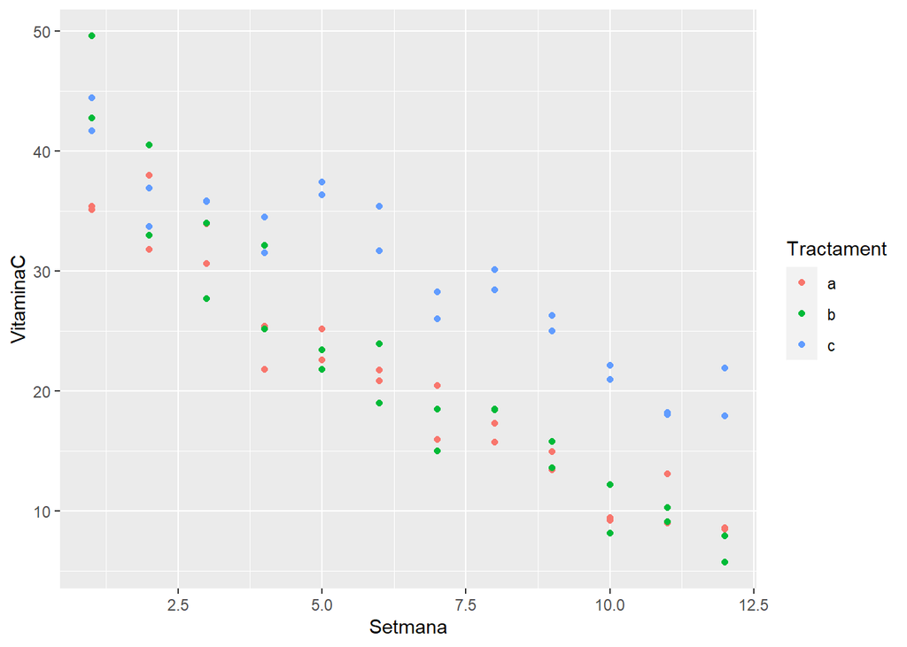

```r
#simple point plot of data
ggplot(data = df) +
  aes(x = Setmana, y = VitaminaC, color = Tractament) +
    geom_point()
```

The correlation between the Vitamin C concentration and the time in weeks is a strong negative correlation at -0.7042. This confirms our eyeballed observation earlier.

```r
# Correlation between Vitamin and Week
cor(x = df$VitaminaC, y = df$Setmana, method = "kendall")
```

```
## [1] -0.7041753
```

**3)** The questions of the juice company that will be covered by our analysis are :  
- Is any treatment significantly better than the others to maintain the Vitamin C concentration?  
- Does the Vitamin C concentration differ at packaging for different treatments?  
- By how much does Vitamin C concentration decrease per week?

**4)** To answer this question, we fit a linear model to the data. As we assume the VitC concentration to be equal at the time of packaging but we are still interested in the effect of the treatment we fit the model with an interaction term but exclude the treatment itself. In mathematical terms this means that we have different $\beta$ for each treatment but our $\alpha$ is the same.
$$VitaminC_i = \alpha e^{\beta_i .week}$$
With $i \in \{a,b,c\}$ for each treatment.

```r
mod1 = lm( pred ~ Setmana * Tractament -Tractament, data = df)
summary(mod1)
```

```
##
## Call:
## lm(formula = pred ~ Setmana * Tractament - Tractament, data = df)
##
## Residuals:
##      Min       1Q   Median       3Q      Max
## -0.37092 -0.07720  0.00218  0.08968  0.27403
##
## Coefficients:
##                      Estimate Std. Error t value Pr(>|t|)
## (Intercept)          3.863145   0.033107 116.686   <2e-16 ***
## Setmana             -0.142302   0.005398 -26.362   <2e-16 ***
## Setmana:Tractamentb -0.003240   0.005168  -0.627    0.533
## Setmana:Tractamentc  0.067061   0.005168  12.976   <2e-16 ***
## ---
## Signif. codes:  0 '***' 0.001 '**' 0.01 '*' 0.05 '.' 0.1 ' ' 1
##
## Residual standard error: 0.1318 on 68 degrees of freedom
## Multiple R-squared:  0.9338, Adjusted R-squared:  0.9309
## F-statistic: 319.9 on 3 and 68 DF,  p-value: < 2.2e-16
```

We can see that the time and the treatment c appear to have a significant effect on the Vitamin C concentration. Let us check that our intercept is actually the same for each treatment. We do this by predicting 3 observations each with week being zero and one for each treatment.

```r
pr.df = data.frame(Setmana = c(0,0,0), Tractament = c("a", "b", "c"))
predict(mod1, pr.df)
```

```
##        1        2        3
## 3.863145 3.863145 3.863145
```

Not let us plot our model so that we can get an understanding of what it looks like:

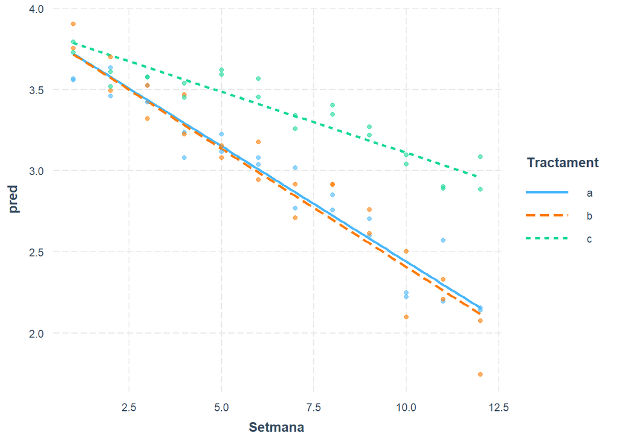

```r
interact_plot(mod1, pred = Setmana, modx = Tractament, plot.points = T)
```

In this model we find that $\alpha = 47.61488$ and $\beta[a,b,c] = [-0.1423, -0.1455, -0.0752]$. The betas are best interpreted if we take the exponential of them and we get: $e^{\beta[a,b,c]} = [0.8674, 0.8646, 0.9276]$. These are the factors we will multiply our VitC Concentration with each week. For example lets consider treatment a: each week the concentration will fall by $1-e^{\beta[a]} = 13.26\%$.

Finally let us check whether the betas are significantly diferent from eachother. We can do this by checking the anova table.

```r
anova(mod1)
```

```
## Analysis of Variance Table
##
## Response: pred
##                    Df  Sum Sq Mean Sq F value    Pr(>F)
## Setmana             1 12.5679 12.5679  723.88 < 2.2e-16 ***
## Setmana:Tractament  2  4.0950  2.0475  117.93 < 2.2e-16 ***
## Residuals          68  1.1806  0.0174
## ---
## Signif. codes:  0 '***' 0.001 '**' 0.01 '*' 0.05 '.' 0.1 ' ' 1
```

We see that the interaction “Setmana:Tractament” is highly significant. This indicates that the betas are indeed different from eachother. We want to provide a little more detail to the meaning of “highly significant”. What we were doing here is an F-Test. First we assume, under the 0-hypothesis, that the effect of the treatment on the week is 0. Then we ask ourselves, under this condition what is the probability of observing the outcome of our data (and technically every more extreme outcome). This is the famous p-value which is 2.2e-16. Thus it is very unlikely to observe the outcome we got, given there is no effect. Following we reject the 0-hypothesis and can say that the effect is non-zero.

**5)** We want to fit a model that does not assume that the treatments have the same Vitamin C concentration at the time of packaging. Thus a linear model that for each slope has a different slope and intercept.
$$VitaminC_i = \alpha_i e^{\beta_i .week}$$
With $i \in \{a,b,c\}$ for each treatment.

```r
mod2 = lm( pred ~ Setmana * Tractament, data = df)
summary(mod2)
```

```
##
## Call:
## lm(formula = pred ~ Setmana * Tractament, data = df)
##
## Residuals:
##      Min       1Q   Median       3Q      Max
## -0.32648 -0.08784 -0.00029  0.09972  0.25357
##
## Coefficients:
##                      Estimate Std. Error t value Pr(>|t|)
## (Intercept)          3.799209   0.056130  67.686  < 2e-16 ***
## Setmana             -0.134630   0.007627 -17.653  < 2e-16 ***
## Tractamentb          0.164939   0.079379   2.078   0.0416 *
## Tractamentc          0.026868   0.079379   0.338   0.7361
## Setmana:Tractamentb -0.023033   0.010786  -2.136   0.0364 *
## Setmana:Tractamentc  0.063837   0.010786   5.919 1.28e-07 ***
## ---
## Signif. codes:  0 '***' 0.001 '**' 0.01 '*' 0.05 '.' 0.1 ' ' 1
##
## Residual standard error: 0.129 on 66 degrees of freedom
## Multiple R-squared:  0.9385, Adjusted R-squared:  0.9338
## F-statistic: 201.3 on 5 and 66 DF,  p-value: < 2.2e-16
```

We can see in the summary that most values are significant at $\alpha = 0.05$ except for the treatment C. For week zero we would predict the following levels of Vitamin C concentration for different treatments.

```
##             A        B       C
## [1,] 44.66586 52.67542 45.8822
```

Now let us have a look at a plot that shows our fitted model for each treatment

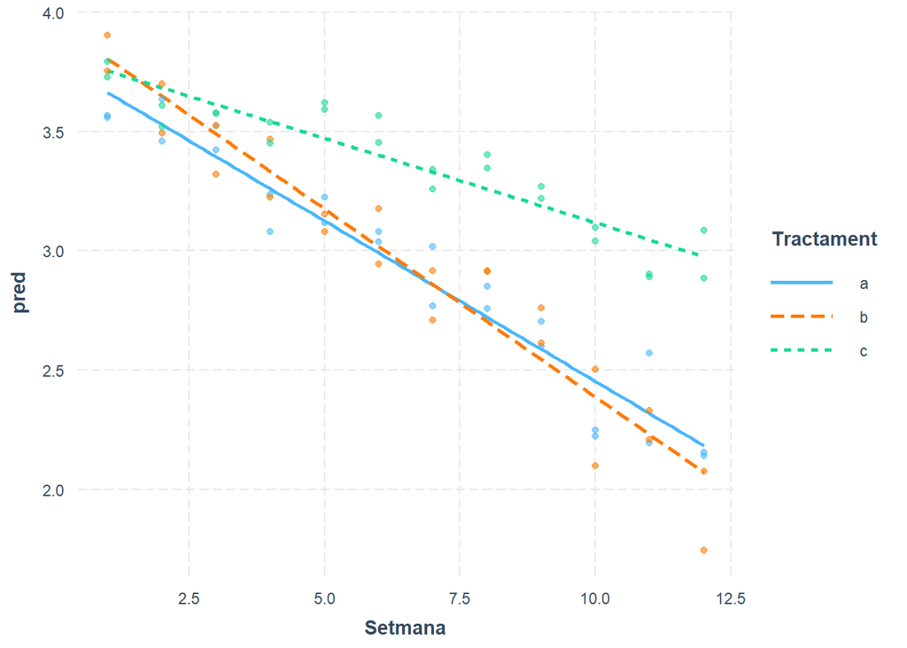

```r
interact_plot(mod2, pred = Setmana, modx = Tractament, plot.points = T)
```

Lastly we want to check whether there is evidence to claim that the treatments have different concentrations of Vitamin C at the time of packaging. We do this by that by assuming the anova method:

```r
anova(mod2)
```

```
## Analysis of Variance Table
##
## Response: pred
##                    Df  Sum Sq Mean Sq F value    Pr(>F)
## Setmana             1 12.5679 12.5679 755.512 < 2.2e-16 ***
## Tractament          2  3.0192  1.5096  90.749 < 2.2e-16 ***
## Setmana:Tractament  2  1.1585  0.5792  34.821 4.741e-11 ***
## Residuals          66  1.0979  0.0166
## ---
## Signif. codes:  0 '***' 0.001 '**' 0.01 '*' 0.05 '.' 0.1 ' ' 1
```

We can clearly see that the variable Tractament is highly significant. This indeed indicates that different treatments lead to a different concentration of VitC at the time of packaging.

**6)** We can choose the best linear model by comparing the Akaike Information Criterion (AIC). We use the function “dredge” from the package “MuMIn” to rank all the possible models by their AIC

```r
options(na.action="na.fail")
all_lm <- lm(pred ~ Setmana + Tractament, data = df)
dredge(all_lm,rank = "AIC")
```

```
## Fixed term is "(Intercept)"
```

```
## Global model call: lm(formula = pred ~ Setmana + Tractament, data = df)
## ---
## Model selection table
##   (Intrc)  Setmn Trctm df  logLik   AIC  delta weight
## 4   3.711 -0.121     +  5  22.501 -35.0   0.00      1
## 2   3.863 -0.121        3  -8.075  22.1  57.15      0
## 3   2.924            +  4 -45.269  98.5 133.54      0
## 1   3.076               2 -51.943 107.9 142.89      0
## Models ranked by AIC(x)
```

We choose the model with the lowest AIC ie.the model considering that the concentration of vitamin C depends both on the week of measurement and on the treatment. It’s AIC is equal to -35.0.

```r
bmod = lm(pred ~ Setmana + Tractament,data=df)
```

We check if the assumptions of regression (linearity, independence of errors, normality of errors and homoscedasticity) are satisfied with a residual analysis.

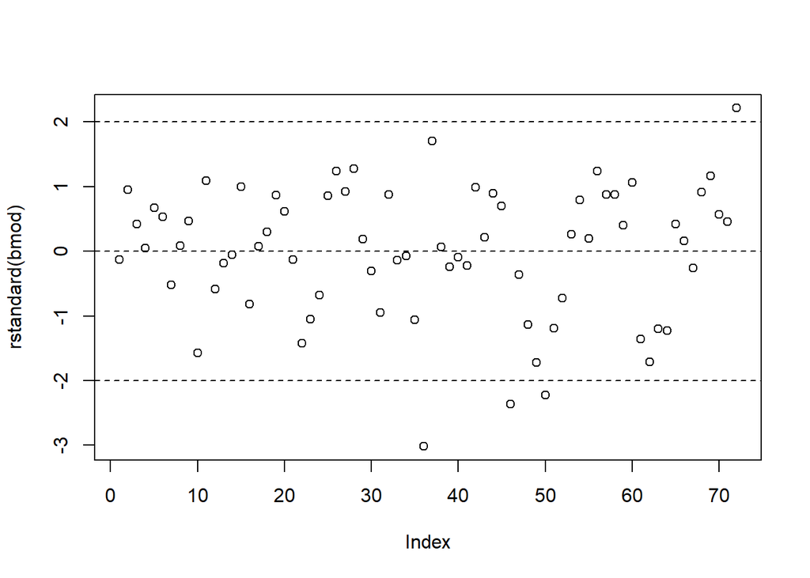

```r
#Residual analysis for linearity

#Standard residual
plot(rstandard(bmod))
abline(h=c(-2,0,2),lty=2)
```

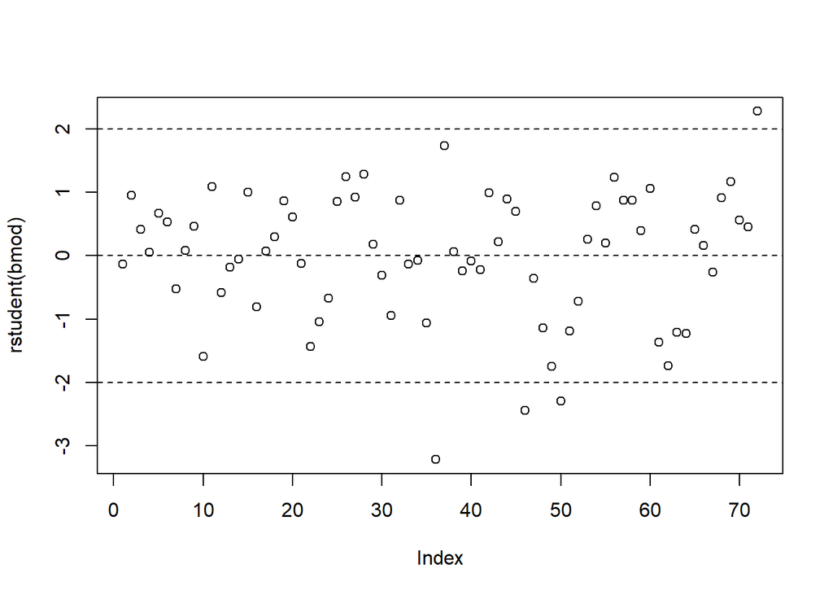

```r
#Studentized residual
plot(rstudent(bmod))
abline(h=c(-2,0,2),lty=2)
```

We see that both residuals plots leads to the conclusion that all the assumptions are satisfied :  
- Most of the residuals are in of the interval [-2,2] (only 4 residuals are out) which confirms the assumptions of linearity, normality of errors and homoscedasticity are satisfied.  
- We don’t see any particular pattern for both plots so we consider that the independence of errors assumption is satisfied.

```r
#Adjusted R^2
summary(bmod)
```

```
##
## Call:
## lm(formula = pred ~ Setmana + Tractament, data = df)
##
## Residuals:
##      Min       1Q   Median       3Q      Max
## -0.52797 -0.10701  0.02144  0.15102  0.38713
##
## Coefficients:
##              Estimate Std. Error t value Pr(>|t|)
## (Intercept)  3.710801   0.054923  67.563  < 2e-16 ***
## Setmana     -0.121028   0.006219 -19.462  < 2e-16 ***
## Tractamentb  0.015225   0.052585   0.290    0.773
## Tractamentc  0.441808   0.052585   8.402 4.09e-12 ***
## ---
## Signif. codes:  0 '***' 0.001 '**' 0.01 '*' 0.05 '.' 0.1 ' ' 1
##
## Residual standard error: 0.1822 on 68 degrees of freedom
## Multiple R-squared:  0.8735, Adjusted R-squared:  0.868
## F-statistic: 156.6 on 3 and 68 DF,  p-value: < 2.2e-16
```

The adjusted R-squared is equal to 0.868, it means that the model explains 86.8% of the fluctuation in Vitamin C, which is a sufficient proportion. The residual standard error being low (equal to 0.1822)g which means that the values of the residuals are pretty close to each other. Moreover, the null hypothesis of the omnibus test is clearly rejected (p-value < 0.05), our “best model” have a way better fit to the data than the null model because the explanatory variables play a huge role in the variability of the vitamin C.

**7)** The goal of our analysis was to study the influence of the treatment and of the week of measurement on the vitamin C concentration of the juice. Our analysis of the dataset provided led to the answers of the following questions :  
- How much does Vitamin C concentration decrease per week?  
- Does the Vitamin C concentration differ at packaging for different treatments?  
- Is there a treatment better than the 2 others in maintaining a high Vitamin C concentration?  
- Are the effects of the week of measurement and the type of treatment on the vitamin C concentration correlated?

In the following line, the term “parameters” will refer to both week of measurement and type of treatment. The analysis we made consisted first on a data analysis that led us to understand the effect of the parameters on the Vitamin C concentration, then, we fitted linear models to the data to better understand the relationships between the effects of the different parameters.

Performing the data analysis, we concluded that the Vitamin C concentration decreases linearly over time by studying the correlation between these two variables. With treatment a and b, the concentrations decreases linearly as the weeks pass by. Besides, treatment C leads to higher concentrations than treatment a and b after the 4th week.

We then fitted a normal linear model to the data to study the effect of the different treatments assuming the Vitamin C concentrations to be equal at the time of packaging. We could conclude that the week of measurement and the treatment c are the “conditions” that seems to affect the most the vitamin C concentration. We then estimated the $\beta_i$, they are factors that represents the effects of each treatment on the vitamin C concentration. The analysis we performed after the estimation allowed us to confirm that these factor are indeed different one from each other which means that each treatment has a different effect on the vitamin C concentration. For treatment a, the concentration fall by 13.26% each week. For treatment b, we can expect a decrease of 13.54% each week. For treatment c, a decrease of 7.24% each week.

Finally, we studied all possible normal linear models to find the one that fit the best our data. We came to the conclusion that both the week of measurement and the treatment have a significant effect on the vitamin C concentration. If ones wants to maintain a high vitamin C concentration in the juice, it is important to choose the treatment that will lead to a higher results overtime (i.e. Treatment c). However, the time when it will be consumed shouldn’t be neglected.